# Cat Perceptions Data

Question A (1): Roaming outdoor cats harm wildlife  
Question B (2): Roaming outdoor cats do not harm wildlife  
Question C (3): People should keep their cats indoors or under a person’s control (e.g., leash, catio) while outdoors  
Question D (4): People need not keep their cats indoors or under a person’s control (e.g., leash, catio) while outdoors  
Question E (5): Pet cats should be spayed or neutered unless intended for breeding  
Question F (6): Pet cats not intended for breeding need not be spayed or neutered  
Question G (7): Pet cats should be microchipped (a microchip is a small identification device inserted under the animal’s skin)  
Question H (8): Pet cats need not be microchipped (a microchip is a small identification device inserted under the animal’s skin)  
Question I (9): Roaming outdoor cats pose a risk to human health  
Question J (10): Roaming outdoor cats do not pose a risk to human health

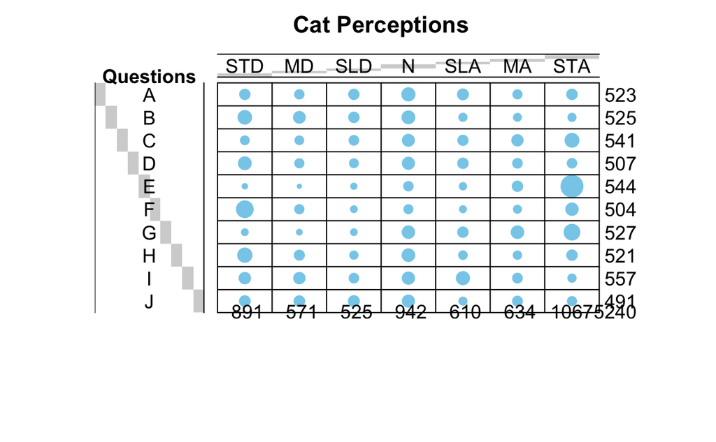

```r
df1 <- read.csv(file = "totals.csv")
library("gplots")
# 1. convert the data as a table
dt <- as.table(as.matrix(df1[,c(4:10)]))
# 2. Graph
balloonplot(t(dt), main ="Cat Perceptions", xlab ="", ylab="Questions",
            label = FALSE, show.margins = TRUE)
```

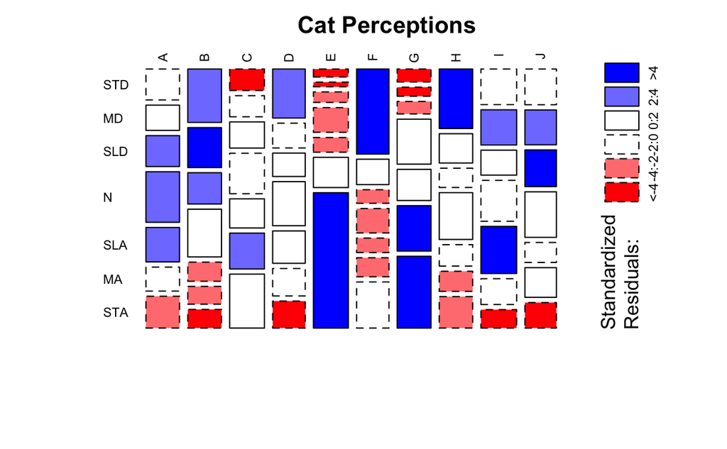

```r
library("graphics")
mosaicplot(dt, shade = TRUE, las=2,
           main = "Cat Perceptions")
```

### Blue color indicates that the observed value is higher than the expected value if the data were random

### Red color specifies that the observed value is lower than the expected value if the data were random

```r
df1 <- read.csv(file = "totals.csv")
db <- df1[,c(4:10)]
#dc <- read.delim(db, row.names = 1)
chisq <- chisq.test(db)
chisq
```

```
    Pearson's Chi-squared test

data:  db
X-squared = 1224.4, df = 54, p-value < 2.2e-16
```

```r
qchisq(.95, df=54)
```

```
[1] 72.15322
```

### The row and the column variables are not independent of each other. This implies that they are significantly associated. If the distribution of this data is due entirely to chance, then you have a 0.00000000…22% chance of finding a discrepancy between the observed and expected distributions that is at least this extreme.

```r
chisq$observed
```

```
      STD MD SLD   N SLA  MA STA
 [1,]  71 58  71 116  79  55  73
 [2,] 123 92  72 110  44  41  43
 [3,]  51 50  62  96  69  85 128
 [4,] 109 55  52  98  72  61  60
 [5,]  19 11  25  59  35  72 323
 [6,] 188 56  30  54  32  42 102
 [7,]  30 21  29 104  72 105 166
 [8,] 136 67  44 107  49  46  72
 [9,]  87 86  61 100 115  63  45
[10,]  77 75  79  98  43  64  55
```

```r
round(chisq$expected,2)
```

```
        STD    MD   SLD      N   SLA    MA    STA
 [1,] 88.93 56.99 52.40  94.02 60.88 63.28 106.50
 [2,] 89.27 57.21 52.60  94.38 61.12 63.52 106.90
 [3,] 91.99 58.95 54.20  97.26 62.98 65.46 110.16
 [4,] 86.21 55.25 50.80  91.14 59.02 61.34 103.24
 [5,] 92.50 59.28 54.50  97.80 63.33 65.82 110.77
 [6,] 85.70 54.92 50.50  90.60 58.67 60.98 102.63
 [7,] 89.61 57.43 52.80  94.74 61.35 63.76 107.31
 [8,] 88.59 56.77 52.20  93.66 60.65 63.04 106.09
 [9,] 94.71 60.70 55.81 100.13 64.84 67.39 113.42
[10,] 83.49 53.50 49.19  88.27 57.16 59.41  99.98
```

```r
round(chisq$residuals, 3)
```

```
         STD     MD    SLD      N    SLA     MA    STA
 [1,] -1.901  0.134  2.570  2.267  2.322 -1.041 -3.246
 [2,]  3.570  4.600  2.675  1.608 -2.189 -2.826 -6.181
 [3,] -4.274 -1.166  1.059 -0.127  0.759  2.416  1.700
 [4,]  2.455 -0.033  0.169  0.718  1.689 -0.044 -4.255
 [5,] -7.642 -6.271 -3.996 -3.923 -3.560  0.762 20.164
 [6,] 11.051  0.146 -2.884 -3.846 -3.482 -2.431 -0.062
 [7,] -6.297 -4.807 -3.275  0.951  1.360  5.164  5.665
 [8,]  5.037  1.357 -1.135  1.378 -1.496 -2.146 -3.310
 [9,] -0.792  3.248  0.695 -0.013  6.229 -0.535 -6.424
[10,] -0.710  2.939  4.250  1.036 -1.873  0.596 -4.498
```

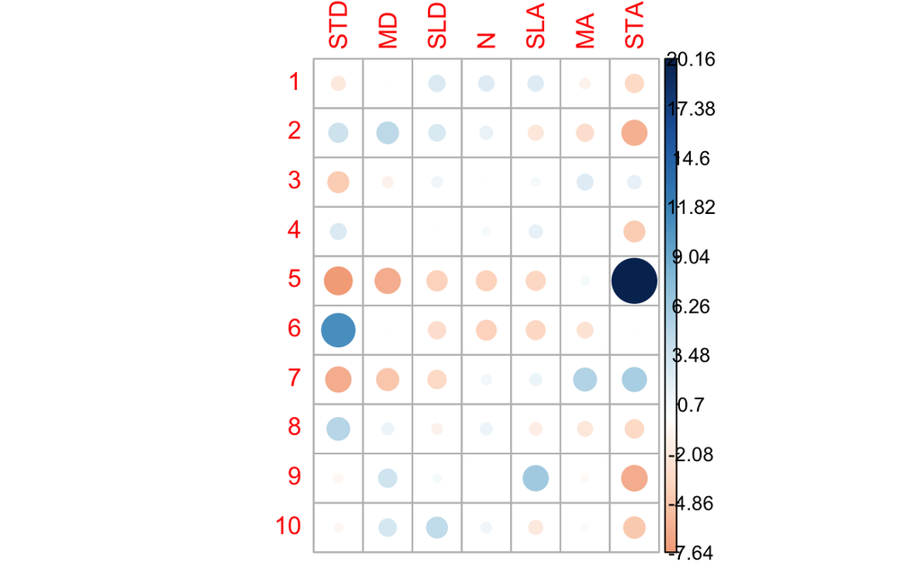

```r
library(corrplot)
corrplot(chisq$residuals, is.cor = FALSE)
```

### Positive residuals are in blue. Positive values in cells specify an attraction (positive association) between the corresponding row and column variables.

### Negative residuals are in red. This implies a repulsion (negative association) between the corresponding row and column variables.

```r
contrib <- 100*chisq$residuals^2/chisq$statistic
round(contrib, 3)
```

```
        STD    MD   SLD     N   SLA    MA    STA
 [1,] 0.295 0.001 0.539 0.420 0.440 0.088  0.860
 [2,] 1.041 1.728 0.584 0.211 0.392 0.652  3.120
 [3,] 1.492 0.111 0.092 0.001 0.047 0.477  0.236
 [4,] 0.492 0.000 0.002 0.042 0.233 0.000  1.479
 [5,] 4.770 3.211 1.304 1.257 1.035 0.047 33.208
 [6,] 9.974 0.002 0.679 1.208 0.990 0.482  0.000
 [7,] 3.239 1.887 0.876 0.074 0.151 2.178  2.621
 [8,] 2.072 0.150 0.105 0.155 0.183 0.376  0.895
 [9,] 0.051 0.862 0.039 0.000 3.169 0.023  3.371
[10,] 0.041 0.705 1.475 0.088 0.286 0.029  1.653
```

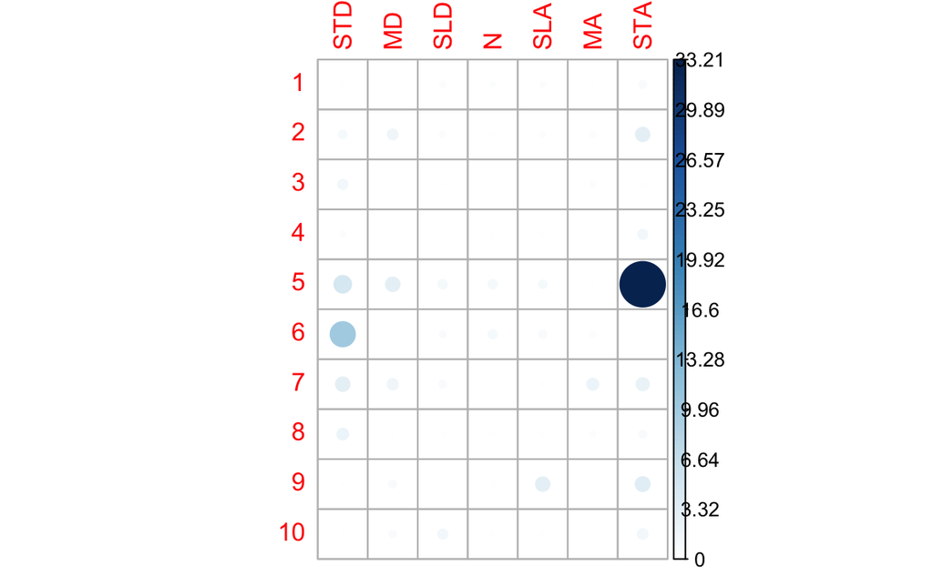

```r
# Visualize the contribution
corrplot(contrib, is.cor = FALSE)
```

### The relative contribution of each cell to the total Chi-square score give some indication of the nature of the dependency between rows and columns of the contingency table.

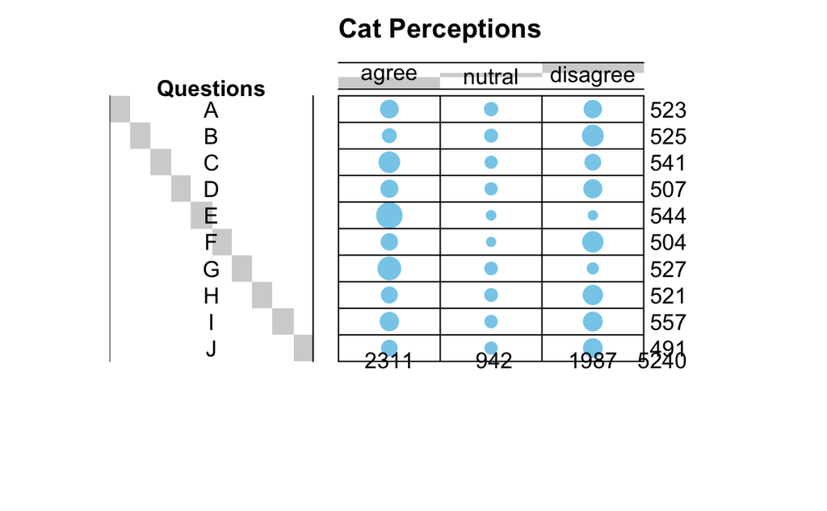

```r
dm <- df1[,c(1,4:10)]
dm$Q <-  c(1:10)
dm$agree <- dm$SLA + dm$MA + dm$STA
dm$nutral <- dm$N
dm$disagree <- dm$SLD + dm$MD + dm$STD
dmsimp <- dm[,9:12]
dt <- as.table(as.matrix(dmsimp[,2:4]))
# 2. Graph
balloonplot(t(dt), main ="Cat Perceptions", xlab ="", ylab="Questions",
            label = FALSE, show.margins = TRUE)
```

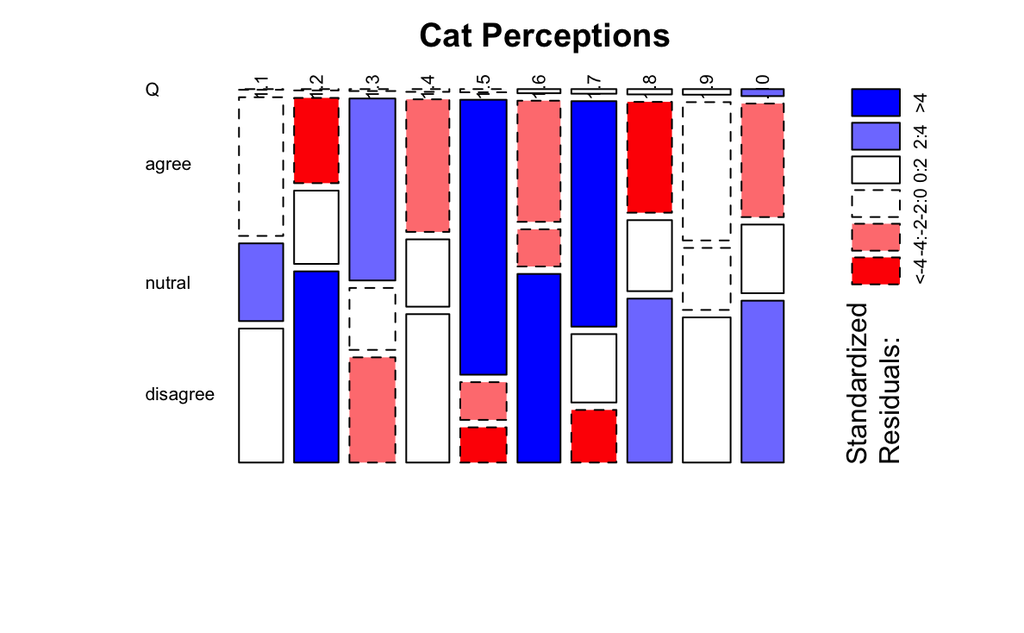

```r
library("graphics")
mosaicplot(dmsimp, shade = TRUE, las=2,
           main = "Cat Perceptions")
```

```r
chisq <- chisq.test(dmsimp[2:4])
chisq
```

```
    Pearson's Chi-squared test

data:  dmsimp[2:4]
X-squared = 643.75, df = 18, p-value < 2.2e-16
```

```r
qchisq(.95, df=18)
```

```
[1] 28.8693
```

```r
chisq$observed
```

```
      agree nutral disagree
 [1,]   207    116      200
 [2,]   128    110      287
 [3,]   282     96      163
 [4,]   193     98      216
 [5,]   430     59       55
 [6,]   176     54      274
 [7,]   343    104       80
 [8,]   167    107      247
 [9,]   223    100      234
[10,]   162     98      231
```

```r
round(chisq$expected,2)
```

```
       agree nutral disagree
 [1,] 230.66  94.02   198.32
 [2,] 231.54  94.38   199.08
 [3,] 238.60  97.26   205.15
 [4,] 223.60  91.14   192.25
 [5,] 239.92  97.80   206.28
 [6,] 222.28  90.60   191.12
 [7,] 232.42  94.74   199.84
 [8,] 229.78  93.66   197.56
 [9,] 245.65 100.13   211.21
[10,] 216.55  88.27   186.19
```

```r
round(chisq$residuals, 3)
```

```
       agree nutral disagree
 [1,] -1.558  2.267    0.119
 [2,] -6.805  1.608    6.231
 [3,]  2.810 -0.127   -2.943
 [4,] -2.047  0.718    1.713
 [5,] 12.272 -3.923  -10.533
 [6,] -3.104 -3.846    5.995
 [7,]  7.253  0.951   -8.477
 [8,] -4.141  1.378    3.517
 [9,] -1.445 -0.013    1.568
[10,] -3.707  1.036    3.284
```

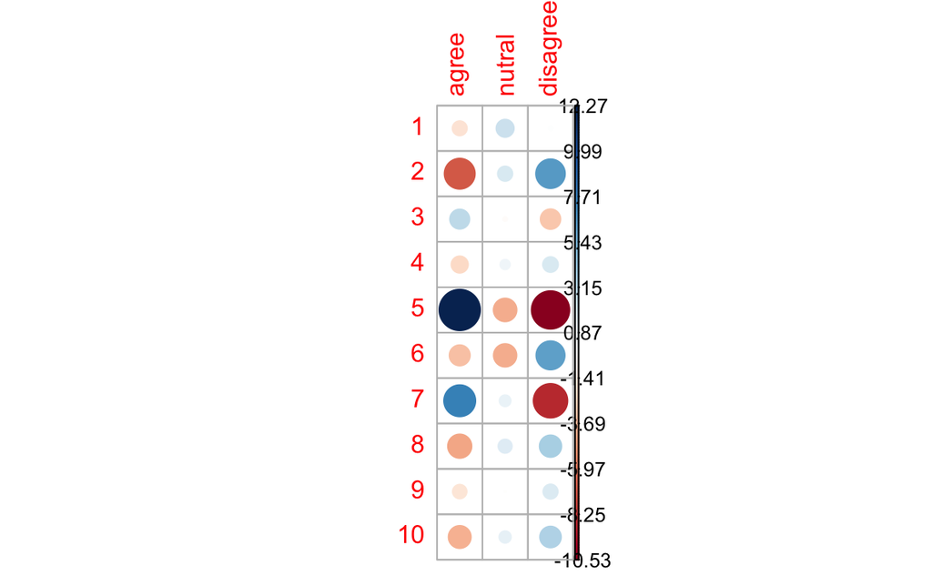

```r
library(corrplot)
corrplot(chisq$residuals, is.cor = FALSE)
```